# My Chi My Future – Poverty Relation to Program opportunities

Author

Sherry Chen

Published

December 9, 2024

Abstract

# 1 Background / Motivation

For many, the financial strain is overwhelming; low-income families allocate nearly one-third of their income to child care, while wealthier families spend only 10%. Compounding this challenge is the inadequacy of existing programs like Early Head Start, which in 2015 reached just 15% of eligible children. Career interruptions caused by child care shortages reduce lifetime earnings by nearly 20%, and in 2018 alone, child care challenges cost parents two work hours weekly and forced many to forgo job or training opportunities altogether ([Illinois Policy](https://www.illinoispolicy.org/poverty-in-chicago-higher-in-2022-than-before-war-on-poverty/#:~:text=Today%2C%20the%20poverty%20rate%20sits,live%20below%20the%20poverty%20line)).

Education is a powerful force for change, enhancing health, livelihoods, and social stability. On an individual level, it leads to better living standards by boosting productivity, as those with higher education often access more economic and social opportunities. On a broader scale, education builds skilled human capital, which drives economic growth and development. However, acquiring knowledge, values, and skills through education is not easy—it is a demanding and ongoing journey. Students must devote significant time to study, striving to graduate with strong academic outcomes.

Initiatives like “MyChi, My Future” offer a path forward, equipping young people with resources for job readiness, mental well-being, and community engagement. The potential benefits are far-reaching: improved health outcomes, reduced risk of chronic diseases, and expanded economic contributions create a more vibrant, resilient society ([BMC Medical Education](https://bmcmededuc.biomedcentral.com/articles/10.1186/s12909-022-03461-0)).

Yet, ensuring that these benefits reach high-need communities remains a censorious challenge. Understanding how socioeconomic factors shape program access is vital to achieving equity. Through this exploratory data analysis, I aimed to uncover whether “MyChi, My Future” effectively engages Chicago’s most underserved populations. By identifying gaps and opportunities, these findings can inform strategies to strengthen future initiatives, transforming lives and shaping a brighter, more equitable future for Chicago’s youth and their communities.

# 2 Problem Statement

I sought to characterize whether communities with high needs (e.g., based on socioeconomic or health indicators) have fewer or less diverse program offerings.

# 3 Data sources

#### 3.0.0.1 [Community Areas in Chicago (Wiki)](https://en.wikipedia.org/wiki/Community_areas_in_Chicago)

Community Areas in Chicago provides demographic and geographic details for Chicago’s 77 community areas, offering insights into population distribution, area size, and density. Each community is identified by a unique number and name, with population figures from the 2020 census and geographic size reported in both square miles and square kilometers. Population density is included, measured in residents per square mile and per square kilometer, allowing for comparisons of how densely populated each area is.This information serves as a foundational resource for exploring disparities among Chicago communities, particularly in spatial, socioeconomic, and demographic contexts.

#### 3.0.0.3 [Chicago Median Income By Zip Code Data (Census)](https://data.census.gov/profile/Chicago_city,_Illinois?g=160XX00US1714000)

The census data provides median income levels for 45 neighborhoods across Chicago, spanning from the southernmost to northernmost areas of the city. It offers valuable insights into the socioeconomic landscape, enabling analysis of income disparities and geographic trends. Additionally, it can be used for correlation studies with other factors such as education, housing, and public services or for market research to understand consumer demographics and neighborhood-specific dynamics.

#### 3.0.0.4 Chicago Geospatial Data (GeoPandas)

Chicago geospatial data with GeoPandas enables mapping and analyzing trends like income, crime, and access to amenities. It simplifies spatial joins, density plots, and is able to offer an easy visualization to many.

# 4 Data quality check / cleaning / preparation

### 4.0.1 Poor Kids Data By Neighborhood

|  | Variable | Type | Missing Values | Unique Values | Top Levels |
| --- | --- | --- | --- | --- | --- |
| 0 | Rank 2009 | Categorical | 0 | 77 | {'70': 1, '58': 1, '21': 1, '16': 1, '76': 1} |
| 1 | Neighborhood | Categorical | 0 | 77 | {'54 – Riverdale': 1, '40 – Washington Park': ... |
| 2 | Total 6-17 | Categorical | 0 | 77 | {'1623': 1, '2860': 1, '7546': 1, '8830': 1, '... |
| 3 | % City’s Youth | Categorical | 0 | 68 | {'1.25': 3, '2.04': 2, '1.1': 2, '0.95': 2, '0... |
| 4 | 12-14 (E.S.) | Categorical | 0 | 75 | {'2601': 2, '514': 2, '795': 1, '1628': 1, '18... |
| 5 | 15-17 (H.S.) | Categorical | 0 | 77 | {'265': 1, '814': 1, '2100': 1, '2747': 1, '16... |
| 6 | Police Districts | Categorical | 0 | 48 | {'04': 7, '08': 5, '22': 4, '16': 4, '25': 3} |

|  | Poor_Percentage |
| --- | --- |
| count | 77.000000 |
| mean | 28.896104 |
| std | 16.195065 |
| min | 2.900000 |
| 25% | 16.500000 |
| 50% | 26.800000 |
| 75% | 39.200000 |
| max | 72.600000 |

### 4.0.2 Chicago Neighborhoods Data Cleaning

Chicago Neighborhoods was filtered to focus the analysis on Chicago-specific data by filtering rows where the city_name equals to Chicago.

Next, I deduplicated the data, and removed all unnecessary columns such as `city_name`, `neighborhood_ascii`, and `city_id`, as well as administrative and metadata fields such as `state_name`, `source`, `timezone`, `county_fips`, `county_name`, and `id` of the data.

To address entries with multiple ZIP codes in a single row, I expanded these rows by splitting the `zips` column (which contained ZIP codes as a space-separated string) into individual entries. Using the `.explode()` method, I created a new row for each ZIP code associated with a neighborhood. This restructuring enhanced the dataset’s granularity and improved compatibility with other ZIP code-specific datasets. Finally, for clarity and consistency, I renamed the `zips` column to `ZIP Code`, making the dataset more intuitive for merging.

|  | lat | lng |
| --- | --- | --- |
| count | 165.000000 | 165.000000 |
| mean | 41.851062 | -87.680202 |
| std | 0.097777 | 0.072981 |
| min | 41.654480 | -87.893490 |
| 25% | 41.771850 | -87.723580 |
| 50% | 41.857180 | -87.672500 |
| 75% | 41.938670 | -87.625190 |
| max | 42.009620 | -87.534900 |

|  | Variable | Type | Missing Values | Unique Values | Top Levels |
| --- | --- | --- | --- | --- | --- |
| 0 | neighborhood | Categorical | 0 | 81 | {'Loop': 6, 'Ohare': 5, 'Near West Side': 5, '... |
| 1 | state_id | Categorical | 0 | 1 | {'IL': 165} |
| 2 | ZIP Code | Categorical | 0 | 60 | {'60632': 7, '60609': 6, '60619': 6, '60628': ... |

### 4.0.3 Final Merged Data with Median Income | My Chi My Future Program

For Median Income data, I first filtered the MyChiMyFuture program data to focus on programs with a maximum age limit of 25 and a minimum age above 25. I then merged this dataset with the median income and renamed the columns with concise labels.

I further cleaned by addressing missing values by imputing zip codes based on the correct neighborhood names and geographic coordinates by seeking a more reliable Chicago dataset online, which provided accurate neighborhood names, latitude, and longitude information. This step ensured the data’s integrity.

To reduce ambiguity in program categorization, I filtered the dataset to include only face-to-face meetings, simplifying the process of identifying programs offering food or scholarships. Although I initially attempted to impute missing capacity values, further investigation revealed that capacity data could not be effectively utilized, as documented in the accompanying code.

Finally, I grouped the data by zip code to analyze program counts and identify correlations. Observing the program categories, I consolidated STEM-related programs.

|  | Variable | Missing Values | Min | Max | Mean | Std Dev |
| --- | --- | --- | --- | --- | --- | --- |
| 0 | Program ID | 0 | 79232.000000 | 211184.000000 | 149489.268610 | 36321.037206 |
| 1 | Latitude | 0 | 41.657200 | 42.022099 | 41.834674 | 0.090878 |
| 2 | Longitude | 0 | -87.785698 | -87.530502 | -87.664808 | 0.053787 |
| 3 | Med_Income | 0 | 19697.000000 | 104763.000000 | 37097.678349 | 13481.860546 |
| 4 | Count_15to19 | 0 | 0.000000 | 7036.000000 | 3755.852309 | 1395.030088 |
| 5 | Median Age | 0 | 30.900000 | 42.800000 | 36.409527 | 3.017465 |
| 6 | Total_Count | 0 | 737.000000 | 92235.000000 | 63649.844240 | 18473.193249 |
| 7 | Below_Poverty12-17 | 0 | 0.000000 | 2639.000000 | 1225.347593 | 652.466899 |
| 8 | Above_Poverty12-17 | 0 | 0.000000 | 6818.000000 | 3372.793756 | 1565.714099 |
| 9 | TotalNonCitizens | 0 | 39.000000 | 19712.000000 | 7019.089978 | 5515.786255 |
| 10 | Value:Count_Person_USCitizenBornInPuertoRicoOr... | 0 | 0.000000 | 3638.000000 | 562.895993 | 736.435128 |
| 11 | Value:Count_Person_USCitizenBornAbroadOfAmeric... | 0 | 0.000000 | 1339.000000 | 609.269942 | 383.002769 |
| 12 | lat | 0 | 41.660140 | 42.009620 | 41.833800 | 0.092632 |
| 13 | lng | 0 | -87.771170 | -87.534900 | -87.664751 | 0.053557 |

|  | Program ID | Latitude | Longitude | Med_Income | Count_15to19 | Median Age | Total_Count | Below_Poverty12-17 | Above_Poverty12-17 | TotalNonCitizens | Value:Count_Person_USCitizenBornInPuertoRicoOrUSIslandAreas | Value:Count_Person_USCitizenBornAbroadOfAmericanParents | lat | lng |
| --- | --- | --- | --- | --- | --- | --- | --- | --- | --- | --- | --- | --- | --- | --- |
| count | 386639.000000 | 386639.000000 | 386639.000000 | 386639.000000 | 386639.000000 | 386639.000000 | 386639.000000 | 386639.000000 | 386639.000000 | 386639.000000 | 386639.000000 | 386639.000000 | 386639.000000 | 386639.000000 |
| mean | 149489.268610 | 41.834674 | -87.664808 | 37097.678349 | 3755.852309 | 36.409527 | 63649.844240 | 1225.347593 | 3372.793756 | 7019.089978 | 562.895993 | 609.269942 | 41.833800 | -87.664751 |
| std | 36321.037206 | 0.090878 | 0.053787 | 13481.860546 | 1395.030088 | 3.017465 | 18473.193249 | 652.466899 | 1565.714099 | 5515.786255 | 736.435128 | 383.002769 | 0.092632 | 0.053557 |
| min | 79232.000000 | 41.657200 | -87.785698 | 19697.000000 | 0.000000 | 30.900000 | 737.000000 | 0.000000 | 0.000000 | 39.000000 | 0.000000 | 0.000000 | 41.660140 | -87.771170 |
| 25% | 117502.000000 | 41.762566 | -87.702507 | 28621.000000 | 2782.000000 | 34.200000 | 49445.000000 | 802.000000 | 2414.000000 | 896.000000 | 60.000000 | 196.000000 | 41.763250 | -87.714000 |
| 50% | 147722.000000 | 41.831699 | -87.666756 | 33462.000000 | 4002.000000 | 35.400000 | 63241.000000 | 1176.000000 | 3129.000000 | 6377.000000 | 364.000000 | 667.000000 | 41.836150 | -87.663520 |
| 75% | 183385.000000 | 41.910099 | -87.628601 | 41620.000000 | 4550.000000 | 37.600000 | 82749.000000 | 1638.000000 | 3774.000000 | 10035.000000 | 720.000000 | 878.000000 | 41.901210 | -87.623370 |
| max | 211184.000000 | 42.022099 | -87.530502 | 104763.000000 | 7036.000000 | 42.800000 | 92235.000000 | 2639.000000 | 6818.000000 | 19712.000000 | 3638.000000 | 1339.000000 | 42.009620 | -87.534900 |

# 5 Exploratory Data Analysis

## 5.1 1 Distribution Plots

### 5.1.1 1a. Density Plot for Program Count

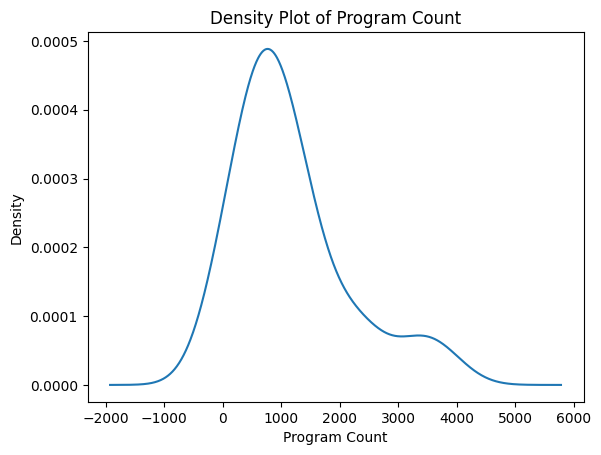

Most neighborhoods have around 1,000 programs, with the distribution slightly skewed to the right, indicating a few neighborhoods with significantly higher program counts. The majority of neighborhoods fall within a lower to mid-range program count.

### 5.1.2 1b. Density Plot of Median Income

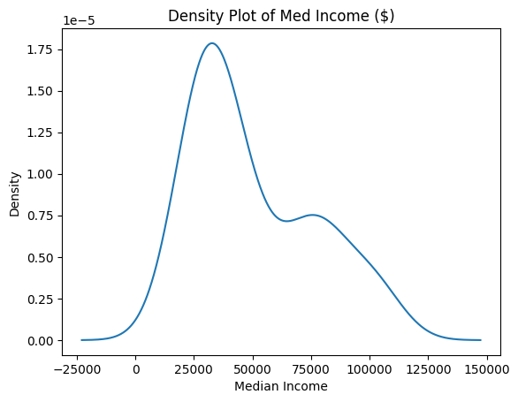

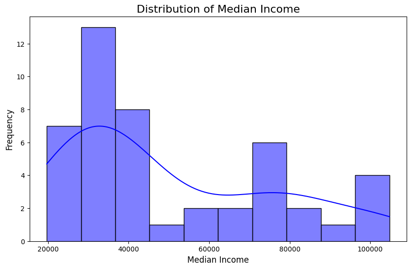

## 5.2 2 Poor Teenager Ratio by Neighborhood Pie Chart

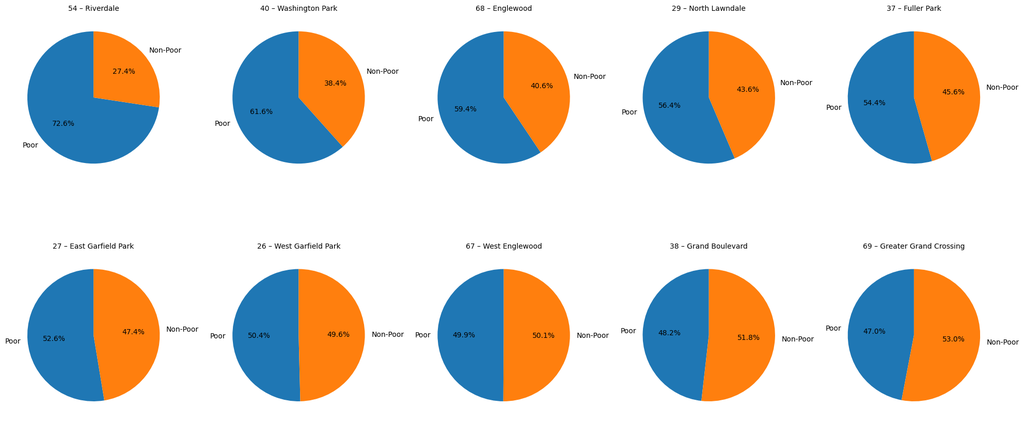

This chart highlights Riverdale, Washington Park, and Englewood as the top three neighborhoods with exceptionally high teen poverty ratios.

## 5.3 3 ScatterPlot (Program Count by Med Income)

Relationship between the count of programs in each zip code and its family income using a scatterplot.

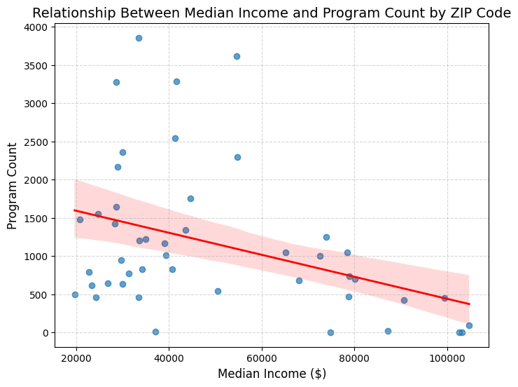

The negative slope in the scatterplot indicates an inverse relationship between median income and program count. This suggests that neighborhoods with lower median incomes tend to have higher program counts, while higher-income neighborhoods have fewer programs. This could imply that more resources and programs are concentrated in lower-income areas, possibly to address greater community needs in those neighborhoods.

## 5.4 4 Geospatial Plotting Scholarship Counts

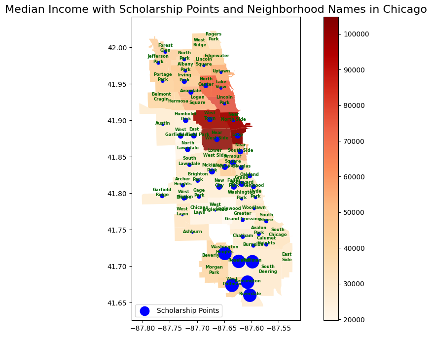

My goal was to paint a clearer picture of how scholarships are spread across different neighborhoods and identify whether disparities exist in the accessibility of these opportunities—especially for lower-income areas. Initially, I thought that socioeconomically disadvantaged neighborhoods might actually have more scholarship opportunities than wealthier parts of the city, given the higher need.

To tackle the question, I first dove into the dataset to analyze the ‘Scholarship Available’ column, filtering out any rows with missing values to ensure my data was clean and reliable. Next, I grouped the data by ZIP code to count the number of programs that offered scholarships in each neighborhood. This approach helped me get an understanding of how scholarships were distributed across Chicago, and where opportunities were abundant or scarce.

My Approach: I then merged the scholarship data with neighborhood information, including latitude and longitude coordinates. This allowed me to creat a map of Chicago overlaid with median income by neighborhood. Scholarship programs were marked as blue points, with the size of each point reflecting the number of scholarship programs available. I also added neighborhood labels to make the map easy to navigate and provide context for where scholarships were located.

Challenges: I faced some challenges, particularly regarding data completeness. For example, I expected the ‘Scholarship Available’ column to have some gaps. I also foresaw complications merging various datasets—especially geographic data—because aligning coordinates and neighborhood names can be a bit like herding cats. On my first attempt, the data merging didn’t go as smoothly as I’d hoped. In particular, inconsistencies between neighborhood names and ZIP codes led to some mismatches during the merge. I had to go back and standardize the data—ensuring all neighborhood names were capitalized consistently and that ZIP codes were formatted properly as strings. Once that was sorted, plotting scholarship availability on the map required several iterations to get it right—from accurately placing the markers to making sure that the visual representation truly conveyed the disparities without getting too cluttered.

Conclusion from Plot: Scholarships are vital in providing pathways to better futures, yet the analysis showed that while many low-income neighborhoods on the south side(Washington Heights, Roseland, Riverdale..) actually had more scholarships available, other parts(Washington Park, Jefferson Park…) of the city were comparatively starved for opportunities.

## 5.5 5 Geospatial Plotting | Pie Chart Free Food Program

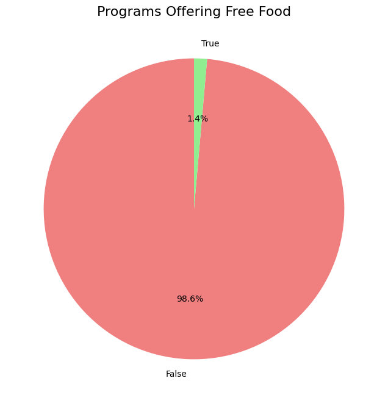

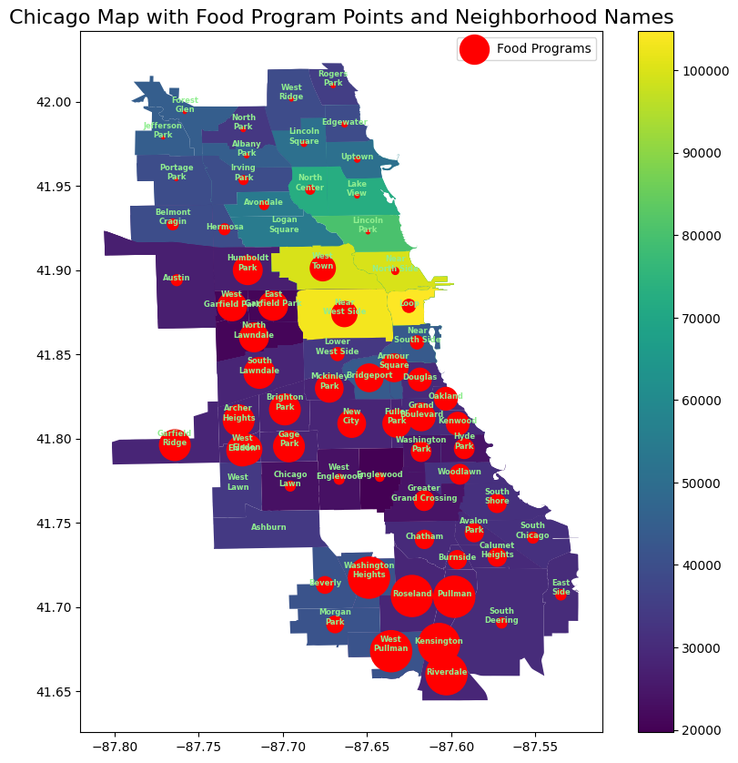

In this analysis, I started by getting rid of rows that had missing data in the ‘Has Free Food’ column and then zeroed in on specific ZIP codes to make things more manageable. I then grouped the program data by ZIP code and counted how many of them offered free food. I threw the results into a pie chart, which revealed a strikingly low number: only 1.4% of all programs were providing free food. That led me to expand my approach—I merged socioeconomic data with the program info to create a layered geographic visualization using GeoPandas(to get a clearer picture of how these programs were distributed spatially).

Challenges: In the ‘Has Free Food’ column, there were a large amount of missing data. It left me with fewer usable records once I filtered them down. Merging different datasets didn’t go smoothly either, with mismatched types and inconsistent neighborhood information causing all sorts of trouble. And then there was that brutal reality check—the fact that only 1.4% of programs were offering free food made it tough to do any sort of meaningful geographic analysis, because there just weren’t enough of them to analyze.

Even visualizing the data took multiple iterations to make sure the maps I was creating actually told a coherent story. The dismal percentage of free food programs also meant I had to shift my focus a bit, looking more closely at the barriers faced by underserved neighborhoods.

## 5.6 6 GeoSpatial Plotting of STEM Program count

```python
finalmerge.groupby("Category Name")["Program ID"].count().reset_index()

# Filter rows where 'Category Name' is one of the STEM categories
stem_categories = ["Computers.", "Digital Media.", "Healthcare", "Math", "Science"]
stem = finalmerge[finalmerge['Category Name'].isin(stem_categories)]
```

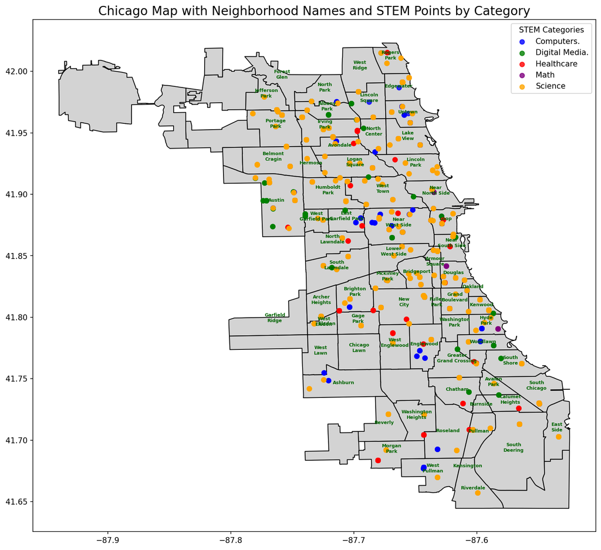

```python
from shapely.geometry import Point
import geopandas as gpd
import matplotlib.pyplot as plt

# Create GeoDataFrame for STEM points
geometry_stem = [Point(xy) for xy in zip(stem["Longitude"], stem["Latitude"])]
points_stem = gpd.GeoDataFrame(stem, geometry=geometry_stem)

# Define a color map for each STEM category
color_map = {
    "Computers.": "blue",
    "Digital Media.": "green",
    "Healthcare": "red",
    "Math": "purple",
    "Science": "orange"
}

# Create GeoDataFrame for Chicago neighborhoods
geometry_zips = [Point(xy) for xy in zip(deduplicated_chicagozips["lng"], deduplicated_chicagozips["lat"])]
points_chicago_zips = gpd.GeoDataFrame(deduplicated_chicagozips, geometry=geometry_zips)

# Plot the Chicago map with combined features
fig, ax = plt.subplots(figsize=(16, 12), dpi=150)  # Increase figure size and DPI for better resolution
chicago.plot(ax=ax, color="lightgrey", edgecolor="black")  # Base map

# Plot STEM categories with different colors
for category, color in color_map.items():
    category_points = points_stem[points_stem["Category Name"] == category]
    category_points.plot(
        ax=ax, color=color, marker="o", alpha=0.8, label=category  # Customize color and transparency
    )

# Add neighborhood names with forced wrapping
for x, y, label in zip(
    points_chicago_zips.geometry.x,
    points_chicago_zips.geometry.y,
    points_chicago_zips["neighborhood"]
):
    # Split label into two lines if it contains a space
    if " " in label:
        label = label.replace(" ", "\n", 1)  # Replace the first space with a newline
    ax.text(
        x, y, label, fontsize=6, fontweight='bold', ha="center", color="darkgreen"  # Slightly larger text for readability
    )

# Add legend and title
plt.legend(title="STEM Categories")
plt.title("Chicago Map with Neighborhood Names and STEM Points by Category", fontsize=16)
plt.show()
```

To explore the data, I grouped program information by category to analyze STEM offerings. I filtered the dataset to focus on relevant STEM categories—Computers, Digital Media, Healthcare, Math, and Science—providing a clearer view of programs of interest. Given varying neighborhood densities, I used distinct colors for each STEM category to ensure clarity.

A major challenge was cluttered or overlapping neighborhood labels, especially in areas with many programs. To improve readability, I implemented label wrapping and adjusted marker transparency.

STEM graduates earn 87% more than non-STEM graduates, yet many low-income neighborhoods lack access to critical STEM programs. While Englewood, Brighton Park, and Ashburn offer computer science programs, Math, Healthcare, and other computer-related fields are notably absent. Currently, only Hyde Park and Douglas provide Math programs—this needs to expand to more underserved neighborhoods.

# 6 7 Conclusions and Recommendations to Stakeholders

Limitations: This analysis did not fully take into account the total population of each neighborhood, which could indicate potential differences in the ratio of programs available. Additionally, I was only able to obtain median income data for certain neighborhoods, which limits the scope of the analysis to the matched data, excluding neighborhoods surrounding Chicago. Furthermore, I couldn’t impute the missing values for the indicator variables related to free food and scholarships, so those missing data points were simply removed.

I found that the MyChiMyFuture program has a small ratio of scholarships and food programs, as well as a low number of Math programs. Stakeholders can work to optimize these areas to ensure a better future for our city and help teenagers better prepare for their futures.

In general, I recommend placing more programs in lower-income neighborhoods. There should also be increased funding in neighborhoods like Englewood and Washington Park, focusing on high-impact programs that are simultaneously engaging and interesting, particularly in Math and Computer Science. Additionally, allocating more scholarships to low-income neighborhoods would help reduce financial barriers to education. To make this realistically achievable, stakeholders should collaborate with local organizations (such as food banks), work with local leaders and schools (e.g., school board meetings to explore ways to increase funding), and engage nearby businesses (to see if they can offer reduced-price food to students). Such collaborations will help ensure that programs are customized to neighborhood needs and reach the intended populations.

# 7 7 References

1. BMC Medical Education. “Exploring factors influencing medical students’ perspectives on their career plans,” [Online]. Available: https://bmcmededuc.biomedcentral.com/articles/10.1186/s12909-022-03461-0.
2. Wikipedia. “Community areas in Chicago,” [Online]. Available: https://en.wikipedia.org/wiki/Community_areas_in_Chicago.
3. Ratcliffe, C. “Child Poverty and Adult Success,” Urban Institute, [Online]. Available: https://www.urban.org/sites/default/files/publication/65766/2000369-Child-Poverty-and-Adult-Success.pdf.
4. OnePlace Onslow. “The Impact of Poverty on Child Care,” [Online]. Available: https://www.oneplaceonslow.org/blog/the-impact-of-poverty-on-child-care/.
5. Springer Open. “Educational Technology Journal: Use of educational technologies during the pandemic,” [Online]. Available: https://educationaltechnologyjournal.springeropen.com/articles/10.1186/s41239-020-0177-7.
6. Google Search. “Poverty in Chicago Research,” [Online]. Available: https://www.google.com/search?q=poverty+chicago+research&rlz=1C1UEAD_enUS1127US1127&oq=poverty+chicago+research&gs_lcrp=EgZjaHJvbWUyBggAEEUYOTIHCAEQIRigATIHCAIQIRigATIHCAMQIRigATIHCAQQIRigATIHCAUQIRigAdIBCDU3ODhqMGo0qAIAsAIA&sourceid=chrome&ie=UTF-8.
7. NORC. “Poverty and Inequality Research Topics,” [Online]. Available: https://www.norc.org/research/topics/poverty-and-inequality.html.

# 8 Appendix

# 9 1 Background / Motivation

For many, the financial strain is overwhelming; low-income families allocate nearly one-third of their income to child care, while wealthier families spend only 10%. Compounding this challenge is the inadequacy of existing programs like Early Head Start, which in 2015 reached just 15% of eligible children. Career interruptions caused by child care shortages reduce lifetime earnings by nearly 20%, and in 2018 alone, child care challenges cost parents two work hours weekly and forced many to forgo job or training opportunities altogether ([Illinois Policy](https://www.illinoispolicy.org/poverty-in-chicago-higher-in-2022-than-before-war-on-poverty/#:~:text=Today%2C%20the%20poverty%20rate%20sits,live%20below%20the%20poverty%20line)).

Education is a powerful force for change, enhancing health, livelihoods, and social stability. On an individual level, it leads to better living standards by boosting productivity, as those with higher education often access more economic and social opportunities. On a broader scale, education builds skilled human capital, which drives economic growth and development. However, acquiring knowledge, values, and skills through education is not easy—it is a demanding and ongoing journey. Students must devote significant time to study, striving to graduate with strong academic outcomes.

Initiatives like “MyChi, My Future” offer a path forward, equipping young people with resources for job readiness, mental well-being, and community engagement. The potential benefits are far-reaching: improved health outcomes, reduced risk of chronic diseases, and expanded economic contributions create a more vibrant, resilient society ([BMC Medical Education](https://bmcmededuc.biomedcentral.com/articles/10.1186/s12909-022-03461-0)).

Yet, ensuring that these benefits reach high-need communities remains a censorious challenge. Understanding how socioeconomic factors shape program access is vital to achieving equity. Through this exploratory data analysis, I aimed to uncover whether “MyChi, My Future” effectively engages Chicago’s most underserved populations. By identifying gaps and opportunities, these findings can inform strategies to strengthen future initiatives, transforming lives and shaping a brighter, more equitable future for Chicago’s youth and their communities.

# 10 2 Problem Statement

I sought to characterize whether communities with high needs (e.g., based on socioeconomic or health indicators) have fewer or less diverse program offerings.

# 11 3 Data sources

#### 11.0.0.1 [Community Areas in Chicago (Wiki)](https://en.wikipedia.org/wiki/Community_areas_in_Chicago)

This dataset provides demographic and geographic details for Chicago’s 77 community areas, offering insights into population distribution, area size, and density. Each community is identified by a unique number and name, with population figures from the 2020 census and geographic size reported in both square miles and square kilometers. Population density is included, measured in residents per square mile and per square kilometer, allowing for comparisons of how densely populated each area is.This information serves as a foundational resource for exploring disparities among Chicago communities, particularly in spatial, socioeconomic, and demographic contexts.

#### 11.0.0.3 [Chicago Median Income By Zip Code Data (Census)](https://data.census.gov/profile/Chicago_city,_Illinois?g=160XX00US1714000)

This dataset provides median income levels for 45 neighborhoods across Chicago, spanning from the southernmost to northernmost areas of the city. It offers valuable insights into the socioeconomic landscape, enabling analysis of income disparities and geographic trends. Additionally, it can be used for correlation studies with other factors such as education, housing, and public services or for market research to understand consumer demographics and neighborhood-specific dynamics.

#### 11.0.0.4 Chicago Geospatial Data (GeoPandas)

Chicago geospatial data with GeoPandas enables mapping and analyzing trends like income, crime, and access to amenities. It simplifies spatial joins, density plots, and is able to offer an easy visualization to many.

# 12 4 Data quality check / cleaning / preparation

### 12.0.1 Poor Kids Data By Neighborhood

|  | Variable | Type | Missing Values | Unique Values | Top Levels |
| --- | --- | --- | --- | --- | --- |
| 0 | Rank 2009 | Categorical | 0 | 77 | {'70': 1, '58': 1, '21': 1, '16': 1, '76': 1} |
| 1 | Neighborhood | Categorical | 0 | 77 | {'54 – Riverdale': 1, '40 – Washington Park': ... |
| 2 | Total 6-17 | Categorical | 0 | 77 | {'1623': 1, '2860': 1, '7546': 1, '8830': 1, '... |
| 3 | % City’s Youth | Categorical | 0 | 68 | {'1.25': 3, '2.04': 2, '1.1': 2, '0.95': 2, '0... |
| 4 | 12-14 (E.S.) | Categorical | 0 | 75 | {'2601': 2, '514': 2, '795': 1, '1628': 1, '18... |
| 5 | 15-17 (H.S.) | Categorical | 0 | 77 | {'265': 1, '814': 1, '2100': 1, '2747': 1, '16... |
| 6 | Police Districts | Categorical | 0 | 48 | {'04': 7, '08': 5, '22': 4, '16': 4, '25': 3} |

|  | Poor_Percentage |
| --- | --- |
| count | 77.000000 |
| mean | 28.896104 |
| std | 16.195065 |
| min | 2.900000 |
| 25% | 16.500000 |
| 50% | 26.800000 |
| 75% | 39.200000 |
| max | 72.600000 |

### 12.0.2 Chicago Neighborhoods Data Cleaning

The dataset initially contained neighborhood data spanning the entire United States. I filtered the dataset to focus the analysis on Chicago-specific data by filtering rows where the city_name equals to Chicago.

Next, I deduplicated the data, and removed all unnecessary columns such as `city_name`, `neighborhood_ascii`, and `city_id`, as well as administrative and metadata fields such as `state_name`, `source`, `timezone`, `county_fips`, `county_name`, and `id` of the data.

To address entries with multiple ZIP codes in a single row, I expanded these rows by splitting the `zips` column (which contained ZIP codes as a space-separated string) into individual entries. Using the `.explode()` method, I created a new row for each ZIP code associated with a neighborhood. This restructuring enhanced the dataset’s granularity and improved compatibility with other ZIP code-specific datasets. Finally, for clarity and consistency, I renamed the `zips` column to `ZIP Code`, making the dataset more intuitive for merging.

|  | lat | lng |
| --- | --- | --- |
| count | 165.000000 | 165.000000 |
| mean | 41.851062 | -87.680202 |
| std | 0.097777 | 0.072981 |
| min | 41.654480 | -87.893490 |
| 25% | 41.771850 | -87.723580 |
| 50% | 41.857180 | -87.672500 |
| 75% | 41.938670 | -87.625190 |
| max | 42.009620 | -87.534900 |

|  | Variable | Type | Missing Values | Unique Values | Top Levels |
| --- | --- | --- | --- | --- | --- |
| 0 | neighborhood | Categorical | 0 | 81 | {'Loop': 6, 'Ohare': 5, 'Near West Side': 5, '... |
| 1 | state_id | Categorical | 0 | 1 | {'IL': 165} |
| 2 | ZIP Code | Categorical | 0 | 60 | {'60632': 7, '60609': 6, '60619': 6, '60628': ... |

### 12.0.3 Final Merged Data with Median Income | My Chi My Future Program

For Median Income data, I first filtered the MyChiMyFuture program data to focus on programs with a maximum age limit of 25 and a minimum age above 25. I then merged this dataset with the median income and renamed the columns with concise labels.

I further cleaned by addressing missing values by imputing zip codes based on the correct neighborhood names and geographic coordinates by seeking a more reliable Chicago dataset online, which provided accurate neighborhood names, latitude, and longitude information. This step ensured the data’s integrity.

To reduce ambiguity in program categorization, I filtered the dataset to include only face-to-face meetings, simplifying the process of identifying programs offering food or scholarships. Although I initially attempted to impute missing capacity values, further investigation revealed that capacity data could not be effectively utilized, as documented in the accompanying code.

Finally, I grouped the data by zip code to analyze program counts and identify correlations. Observing the program categories, I consolidated STEM-related programs.

|  | Variable | Missing Values | Min | Max | Mean | Std Dev |
| --- | --- | --- | --- | --- | --- | --- |
| 0 | Program ID | 0 | 79232.000000 | 211184.000000 | 149489.268610 | 36321.037206 |
| 1 | Latitude | 0 | 41.657200 | 42.022099 | 41.834674 | 0.090878 |
| 2 | Longitude | 0 | -87.785698 | -87.530502 | -87.664808 | 0.053787 |
| 3 | Med_Income | 0 | 19697.000000 | 104763.000000 | 37097.678349 | 13481.860546 |
| 4 | Count_15to19 | 0 | 0.000000 | 7036.000000 | 3755.852309 | 1395.030088 |
| 5 | Median Age | 0 | 30.900000 | 42.800000 | 36.409527 | 3.017465 |
| 6 | Total_Count | 0 | 737.000000 | 92235.000000 | 63649.844240 | 18473.193249 |
| 7 | Below_Poverty12-17 | 0 | 0.000000 | 2639.000000 | 1225.347593 | 652.466899 |
| 8 | Above_Poverty12-17 | 0 | 0.000000 | 6818.000000 | 3372.793756 | 1565.714099 |
| 9 | TotalNonCitizens | 0 | 39.000000 | 19712.000000 | 7019.089978 | 5515.786255 |
| 10 | Value:Count_Person_USCitizenBornInPuertoRicoOr... | 0 | 0.000000 | 3638.000000 | 562.895993 | 736.435128 |
| 11 | Value:Count_Person_USCitizenBornAbroadOfAmeric... | 0 | 0.000000 | 1339.000000 | 609.269942 | 383.002769 |
| 12 | lat | 0 | 41.660140 | 42.009620 | 41.833800 | 0.092632 |
| 13 | lng | 0 | -87.771170 | -87.534900 | -87.664751 | 0.053557 |

|  | Program ID | Latitude | Longitude | Med_Income | Count_15to19 | Median Age | Total_Count | Below_Poverty12-17 | Above_Poverty12-17 | TotalNonCitizens | Value:Count_Person_USCitizenBornInPuertoRicoOrUSIslandAreas | Value:Count_Person_USCitizenBornAbroadOfAmericanParents | lat | lng |
| --- | --- | --- | --- | --- | --- | --- | --- | --- | --- | --- | --- | --- | --- | --- |
| count | 386639.000000 | 386639.000000 | 386639.000000 | 386639.000000 | 386639.000000 | 386639.000000 | 386639.000000 | 386639.000000 | 386639.000000 | 386639.000000 | 386639.000000 | 386639.000000 | 386639.000000 | 386639.000000 |
| mean | 149489.268610 | 41.834674 | -87.664808 | 37097.678349 | 3755.852309 | 36.409527 | 63649.844240 | 1225.347593 | 3372.793756 | 7019.089978 | 562.895993 | 609.269942 | 41.833800 | -87.664751 |
| std | 36321.037206 | 0.090878 | 0.053787 | 13481.860546 | 1395.030088 | 3.017465 | 18473.193249 | 652.466899 | 1565.714099 | 5515.786255 | 736.435128 | 383.002769 | 0.092632 | 0.053557 |
| min | 79232.000000 | 41.657200 | -87.785698 | 19697.000000 | 0.000000 | 30.900000 | 737.000000 | 0.000000 | 0.000000 | 39.000000 | 0.000000 | 0.000000 | 41.660140 | -87.771170 |
| 25% | 117502.000000 | 41.762566 | -87.702507 | 28621.000000 | 2782.000000 | 34.200000 | 49445.000000 | 802.000000 | 2414.000000 | 896.000000 | 60.000000 | 196.000000 | 41.763250 | -87.714000 |
| 50% | 147722.000000 | 41.831699 | -87.666756 | 33462.000000 | 4002.000000 | 35.400000 | 63241.000000 | 1176.000000 | 3129.000000 | 6377.000000 | 364.000000 | 667.000000 | 41.836150 | -87.663520 |
| 75% | 183385.000000 | 41.910099 | -87.628601 | 41620.000000 | 4550.000000 | 37.600000 | 82749.000000 | 1638.000000 | 3774.000000 | 10035.000000 | 720.000000 | 878.000000 | 41.901210 | -87.623370 |
| max | 211184.000000 | 42.022099 | -87.530502 | 104763.000000 | 7036.000000 | 42.800000 | 92235.000000 | 2639.000000 | 6818.000000 | 19712.000000 | 3638.000000 | 1339.000000 | 42.009620 | -87.534900 |

# 13 6 Exploratory Data Analysis

## 13.1 6.1 Distribution Plots

### 13.1.1 1a. Density Plot for Program Count

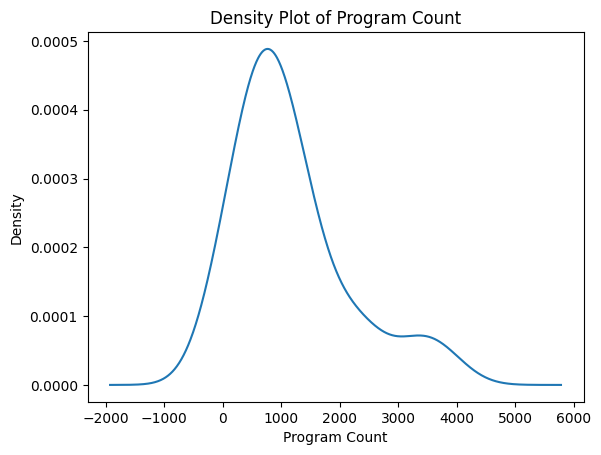

Most neighborhoods have around 1,000 programs, with the distribution slightly skewed to the right, indicating a few neighborhoods with significantly higher program counts. The majority of neighborhoods fall within a lower to mid-range program count.

### 13.1.2 1b. Density Plot of Median Income

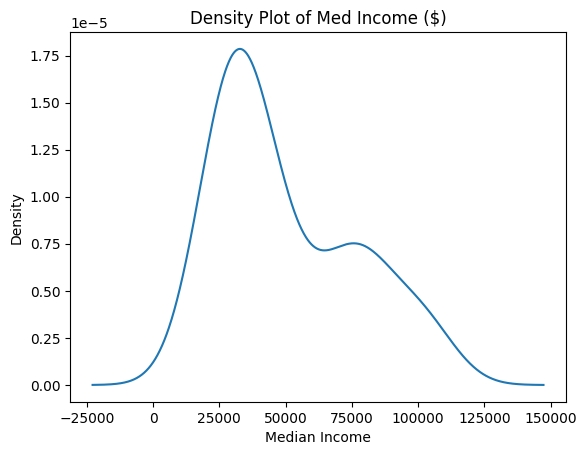

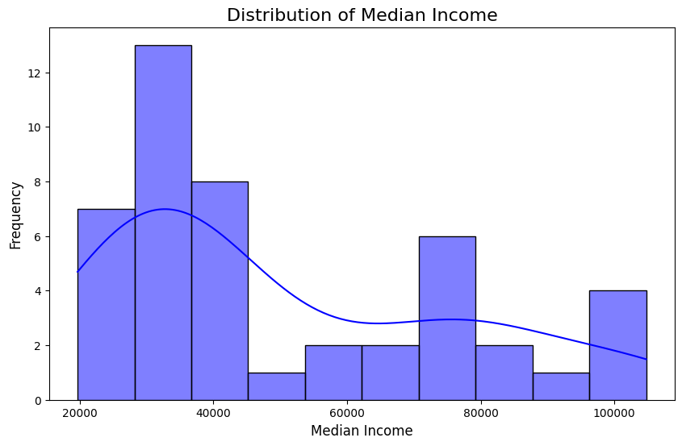

## 13.2 6.2 Poor Teenager Ratio by Neighborhood Pie Chart

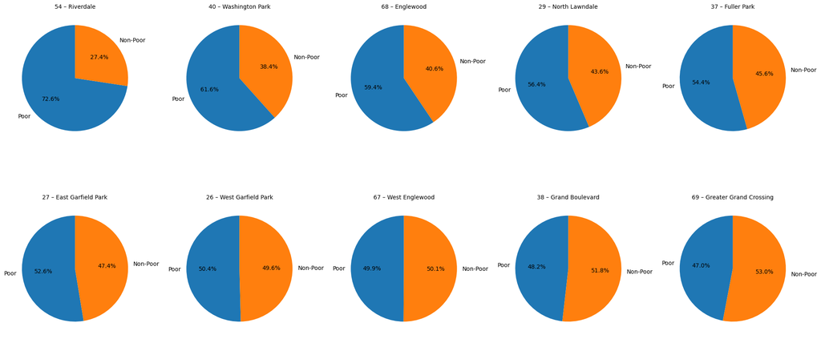

This chart highlights Riverdale, Washington Park, and Englewood as the top three neighborhoods with exceptionally high teen poverty ratios.

## 13.3 6.3 ScatterPlot (Program Count by Med Income)

Relationship between the count of programs in each zip code and its family income using a scatterplot.

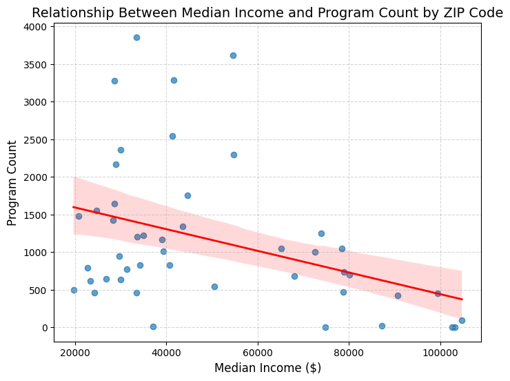

The negative slope in the scatterplot indicates an inverse relationship between median income and program count. This suggests that neighborhoods with lower median incomes tend to have higher program counts, while higher-income neighborhoods have fewer programs. This could imply that more resources and programs are concentrated in lower-income areas, possibly to address greater community needs in those neighborhoods.

## 13.4 6.4 Geospatial Plotting Scholarship Counts

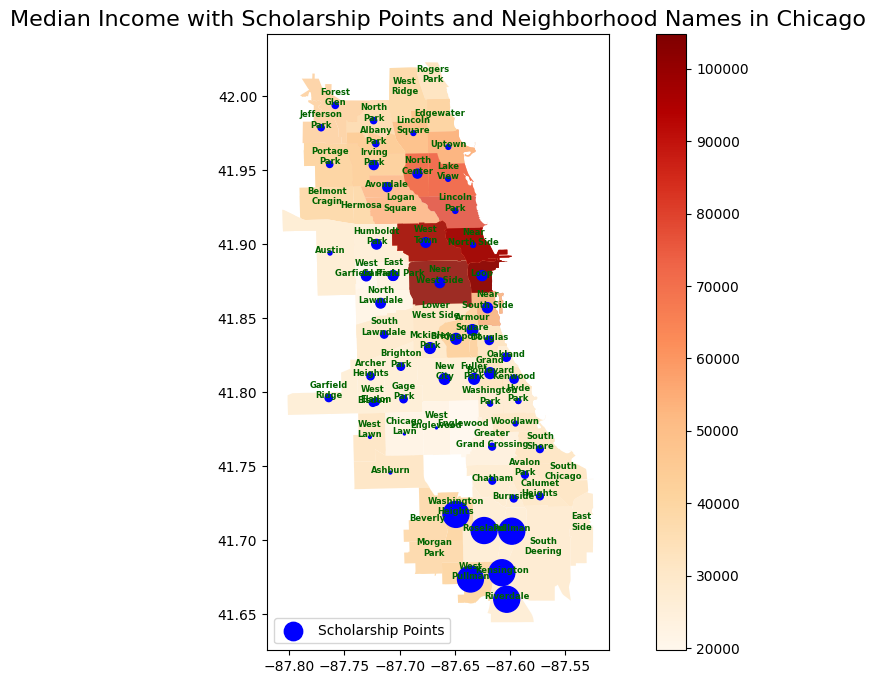

My goal was to paint a clearer picture of how scholarships are spread across different neighborhoods and identify whether disparities exist in the accessibility of these opportunities—especially for lower-income areas. Initially, I thought that socioeconomically disadvantaged neighborhoods might actually have more scholarship opportunities than wealthier parts of the city, given the higher need.

To tackle the question, I first dove into the dataset to analyze the ‘Scholarship Available’ column, filtering out any rows with missing values to ensure my data was clean and reliable. Next, I grouped the data by ZIP code to count the number of programs that offered scholarships in each neighborhood. This approach helped me get an understanding of how scholarships were distributed across Chicago, and where opportunities were abundant or scarce.

My Approach: I then merged the scholarship data with neighborhood information, including latitude and longitude coordinates. This allowed me to creat a map of Chicago overlaid with median income by neighborhood. Scholarship programs were marked as blue points, with the size of each point reflecting the number of scholarship programs available. I also added neighborhood labels to make the map easy to navigate and provide context for where scholarships were located.

Challenges: I faced some challenges, particularly regarding data completeness. For example, I expected the ‘Scholarship Available’ column to have some gaps. I also foresaw complications merging various datasets—especially geographic data—because aligning coordinates and neighborhood names can be a bit like herding cats. On my first attempt, the data merging didn’t go as smoothly as I’d hoped. In particular, inconsistencies between neighborhood names and ZIP codes led to some mismatches during the merge. I had to go back and standardize the data—ensuring all neighborhood names were capitalized consistently and that ZIP codes were formatted properly as strings. Once that was sorted, plotting scholarship availability on the map required several iterations to get it right—from accurately placing the markers to making sure that the visual representation truly conveyed the disparities without getting too cluttered.

Conclusion from Plot: Scholarships are vital in providing pathways to better futures, yet the analysis showed that while many low-income neighborhoods on the south side(Washington Heights, Roseland, Riverdale..) actually had more scholarships available, other parts(Washington Park, Jefferson Park…) of the city were comparatively starved for opportunities.

## 13.5 6.5 Geospatial Plotting | Pie Chart Free Food Program

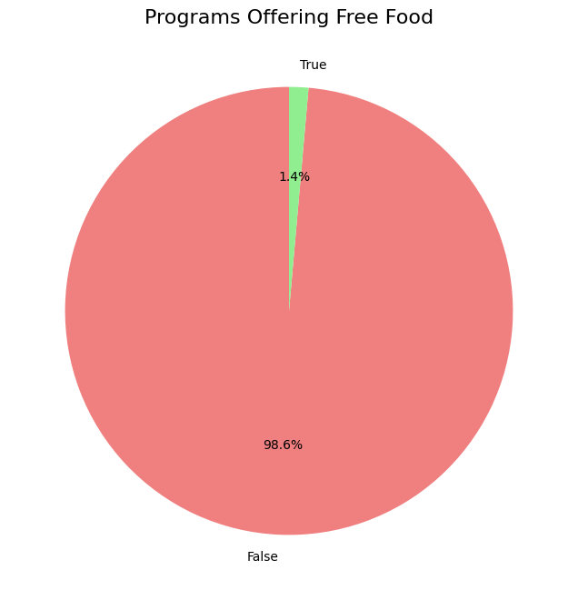

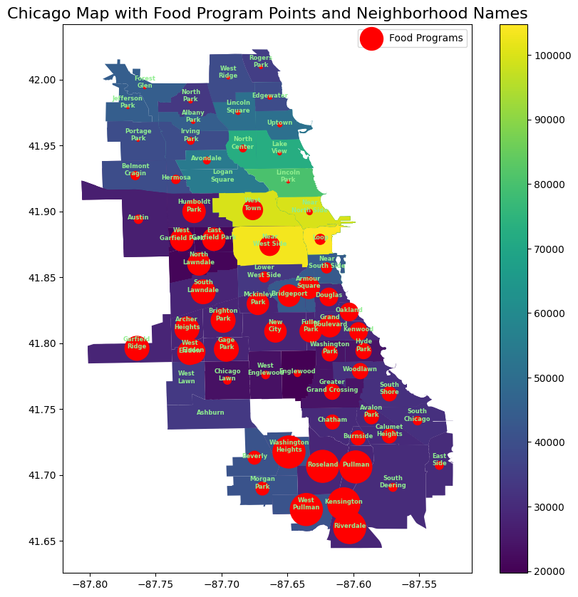

In this analysis, I started by getting rid of rows that had missing data in the ‘Has Free Food’ column and then zeroed in on specific ZIP codes to make things more manageable. I then grouped the program data by ZIP code and counted how many of them offered free food. I threw the results into a pie chart, which revealed a strikingly low number: only 1.4% of all programs were providing free food. That led me to expand my approach—I merged socioeconomic data with the program info to create a layered geographic visualization using GeoPandas(to get a clearer picture of how these programs were distributed spatially).

Challenges: In the ‘Has Free Food’ column, there were a large amount of missing data. It left me with fewer usable records once I filtered them down. Merging different datasets didn’t go smoothly either, with mismatched types and inconsistent neighborhood information causing all sorts of trouble. And then there was that brutal reality check—the fact that only 1.4% of programs were offering free food made it tough to do any sort of meaningful geographic analysis, because there just weren’t enough of them to analyze.

Even visualizing the data took multiple iterations to make sure the maps I was creating actually told a coherent story. The dismal percentage of free food programs also meant I had to shift my focus a bit, looking more closely at the barriers faced by underserved neighborhoods.

## 13.6 6.6 GeoSpatial Plotting of STEM Program count

```python
finalmerge.groupby("Category Name")["Program ID"].count().reset_index()

# Filter rows where 'Category Name' is one of the STEM categories
stem_categories = ["Computers.", "Digital Media.", "Healthcare", "Math", "Science"]
stem = finalmerge[finalmerge['Category Name'].isin(stem_categories)]
```

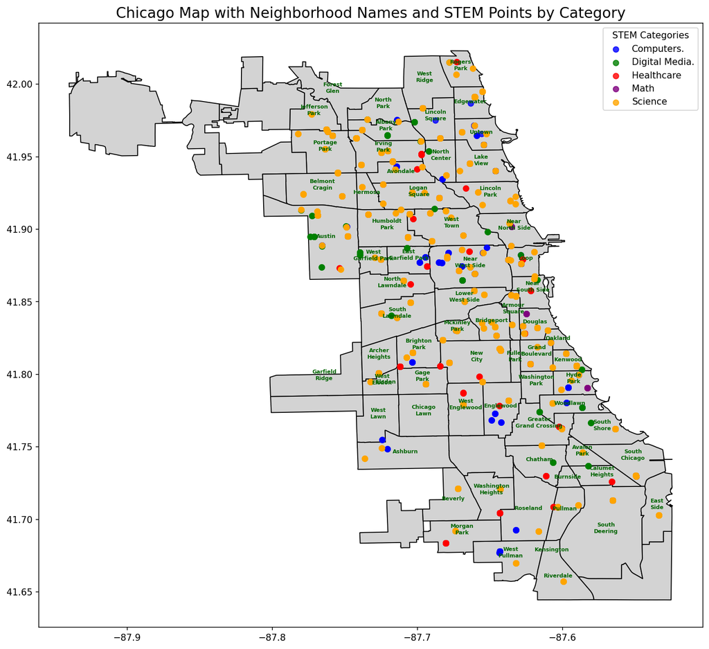

```python
from shapely.geometry import Point
import geopandas as gpd
import matplotlib.pyplot as plt

# Create GeoDataFrame for STEM points
geometry_stem = [Point(xy) for xy in zip(stem["Longitude"], stem["Latitude"])]
points_stem = gpd.GeoDataFrame(stem, geometry=geometry_stem)

# Define a color map for each STEM category
color_map = {
    "Computers.": "blue",
    "Digital Media.": "green",
    "Healthcare": "red",
    "Math": "purple",
    "Science": "orange"
}

# Create GeoDataFrame for Chicago neighborhoods
geometry_zips = [Point(xy) for xy in zip(deduplicated_chicagozips["lng"], deduplicated_chicagozips["lat"])]
points_chicago_zips = gpd.GeoDataFrame(deduplicated_chicagozips, geometry=geometry_zips)

# Plot the Chicago map with combined features
fig, ax = plt.subplots(figsize=(16, 12), dpi=150)  # Increase figure size and DPI for better resolution
chicago.plot(ax=ax, color="lightgrey", edgecolor="black")  # Base map

# Plot STEM categories with different colors
for category, color in color_map.items():
    category_points = points_stem[points_stem["Category Name"] == category]
    category_points.plot(
        ax=ax, color=color, marker="o", alpha=0.8, label=category  # Customize color and transparency
    )

# Add neighborhood names with forced wrapping
for x, y, label in zip(
    points_chicago_zips.geometry.x,
    points_chicago_zips.geometry.y,
    points_chicago_zips["neighborhood"]
):
    # Split label into two lines if it contains a space
    if " " in label:
        label = label.replace(" ", "\n", 1)  # Replace the first space with a newline
    ax.text(
        x, y, label, fontsize=6, fontweight='bold', ha="center", color="darkgreen"  # Slightly larger text for readability
    )

# Add legend and title
plt.legend(title="STEM Categories")
plt.title("Chicago Map with Neighborhood Names and STEM Points by Category", fontsize=16)
plt.show()
```

To explore the data, I grouped program information by category to analyze STEM offerings. I filtered the dataset to focus on relevant STEM categories—Computers, Digital Media, Healthcare, Math, and Science—providing a clearer view of programs of interest. Given varying neighborhood densities, I used distinct colors for each STEM category to ensure clarity.

A major challenge was cluttered or overlapping neighborhood labels, especially in areas with many programs. To improve readability, I implemented label wrapping and adjusted marker transparency.

STEM graduates earn 87% more than non-STEM graduates, yet many low-income neighborhoods lack access to critical STEM programs. While Englewood, Brighton Park, and Ashburn offer computer science programs, Math, Healthcare, and other computer-related fields are notably absent. Currently, only Hyde Park and Douglas provide Math programs—this needs to expand to more underserved neighborhoods.

# 14 7 Conclusions and Recommendations to Stakeholders

Limitations: This analysis did not fully take into account the total population of each neighborhood, which could indicate potential differences in the ratio of programs available. Additionally, I was only able to obtain median income data for certain neighborhoods, which limits the scope of the analysis to the matched data, excluding neighborhoods surrounding Chicago. Furthermore, I couldn’t impute the missing values for the indicator variables related to free food and scholarships, so those missing data points were simply removed.

I found that the MyChiMyFuture program has a small ratio of scholarships and food programs, as well as a low number of Math programs. Stakeholders can work to optimize these areas to ensure a better future for our city and help teenagers better prepare for their futures.

In general, I recommend placing more programs in lower-income neighborhoods. There should also be increased funding in neighborhoods like Englewood and Washington Park, focusing on high-impact programs that are simultaneously engaging and interesting, particularly in Math and Computer Science. Additionally, allocating more scholarships to low-income neighborhoods would help reduce financial barriers to education. To make this realistically achievable, stakeholders should collaborate with local organizations (such as food banks), work with local leaders and schools (e.g., school board meetings to explore ways to increase funding), and engage nearby businesses (to see if they can offer reduced-price food to students). Such collaborations will help ensure that programs are customized to neighborhood needs and reach the intended populations.

# 15 7 References

1. BMC Medical Education. “Exploring factors influencing medical students’ perspectives on their career plans,” [Online]. Available: https://bmcmededuc.biomedcentral.com/articles/10.1186/s12909-022-03461-0.
2. Wikipedia. “Community areas in Chicago,” [Online]. Available: https://en.wikipedia.org/wiki/Community_areas_in_Chicago.
3. Ratcliffe, C. “Child Poverty and Adult Success,” Urban Institute, [Online]. Available: https://www.urban.org/sites/default/files/publication/65766/2000369-Child-Poverty-and-Adult-Success.pdf.
4. OnePlace Onslow. “The Impact of Poverty on Child Care,” [Online]. Available: https://www.oneplaceonslow.org/blog/the-impact-of-poverty-on-child-care/.
5. Springer Open. “Educational Technology Journal: Use of educational technologies during the pandemic,” [Online]. Available: https://educationaltechnologyjournal.springeropen.com/articles/10.1186/s41239-020-0177-7.
6. Google Search. “Poverty in Chicago Research,” [Online]. Available: https://www.google.com/search?q=poverty+chicago+research&rlz=1C1UEAD_enUS1127US1127&oq=poverty+chicago+research&gs_lcrp=EgZjaHJvbWUyBggAEEUYOTIHCAEQIRigATIHCAIQIRigATIHCAMQIRigATIHCAQQIRigATIHCAUQIRigAdIBCDU3ODhqMGo0qAIAsAIA&sourceid=chrome&ie=UTF-8.
7. NORC. “Poverty and Inequality Research Topics,” [Online]. Available: https://www.norc.org/research/topics/poverty-and-inequality.html.

# 16 Appendix